# Homework 06

Adrian Wiegman

February 21, 2018

1. Set up a new .Rmd file for this exercise. Copy and paste the code below into different code chunks, and then read the text and run the code chunks one at a time to see what they do. You probably won’t understand everything in the code, but this is a good start for seeing some realistic uses of ggplot. We will cover most of these details in the next few weeks.
2. Once the code is in and runs, try reading in your own .csv file into a data frame with this code chunk:
3. Once your data are in, go ahead and comment out the “fake data” that are simulated in the chunk below. At that point, if you compile the entire file, it should run all of the code on your own data. Be sure to add comments to the code and commentary to the .Rmd file so that you can go back to it later and understand and use the code in your work.
4. Take a look at the second-to-last graph which shows the histogram of your data and 4 probability density curves (normal, uniform, exponential, gamma) that are fit to the data. The beta distribution in the final graph is somewhat special. It often fits the data pretty well, but that is because we have assumed the largest data point is the true upper bound, and everything is scaled to that. The fit of the uniform distribution also fixes the upper bound. The other curves (normal, exponential, and gamma) are more realistic because they do not have an upper bound. For most data sets, the gamma will probably fit best, but if you data set is small, it may be very hard to see much of a difference between the curves.
5. Using the best-fitting distribution, go back to the code and get the maximum likelihood parameters. Use those to simulate a new data set, with the same length as your original vector, and plot that in a histogram and add the probability density curve. Right below that, generate a fresh histogram plot of the original data, and also include the probability density curve.

## Load Packages and Perform Necessary Data Manipulations

```r
#load packages
library(readr)
#install.packages('fitdistrplus') # for AIC
library(ggplot2) # for graphics
library(MASS) # for maximum likelihood estimation

#Define functions


#Load data
dataset <- USGSdata <- read_delim("USGSdata.txt", delim="\t", escape_double=FALSE, comment="#",trim_ws = TRUE)
View(dataset)
str(dataset)
```

```
## Classes 'tbl_df', 'tbl' and 'data.frame':    69518 obs. of  7 variables:
##  $ id  : chr  "04282000" "04282000" "04282000" "04282000" ...
##  $ YYYY: int  2016 2016 2016 2016 2016 2016 2016 2016 2016 2016 ...
##  $ MM  : int  10 10 10 10 10 10 10 10 10 10 ...
##  $ DD  : chr  "01" "01" "01" "01" ...
##  $ hh  : chr  "00" "00" "00" "00" ...
##  $ mm  : chr  "00" "15" "30" "45" ...
##  $ Q   : num  54.9 54.9 54 54 54 54 53.1 54 54 54.9 ...
##  - attr(*, "spec")=List of 2
##   ..$ cols   :List of 7
##   .. ..$ id  : list()
##   .. .. ..- attr(*, "class")= chr  "collector_character" "collector"
##   .. ..$ YYYY: list()
##   .. .. ..- attr(*, "class")= chr  "collector_integer" "collector"
##   .. ..$ MM  : list()
##   .. .. ..- attr(*, "class")= chr  "collector_integer" "collector"
##   .. ..$ DD  : list()
##   .. .. ..- attr(*, "class")= chr  "collector_character" "collector"
##   .. ..$ hh  : list()
##   .. .. ..- attr(*, "class")= chr  "collector_character" "collector"
##   .. ..$ mm  : list()
##   .. .. ..- attr(*, "class")= chr  "collector_character" "collector"
##   .. ..$ Q   : list()
##   .. .. ..- attr(*, "class")= chr  "collector_double" "collector"
##   ..$ default: list()
##   .. ..- attr(*, "class")= chr  "collector_guess" "collector"
##   ..- attr(*, "class")= chr "col_spec"
```

```r
#Subset data
Middlebury <- dataset[which(dataset$id=="04282000"),]
Rutland <- dataset[which(dataset$id!="04282500"),]
str(Rutland)
```

```
## Classes 'tbl_df', 'tbl' and 'data.frame':    34482 obs. of  7 variables:
##  $ id  : chr  "04282000" "04282000" "04282000" "04282000" ...
##  $ YYYY: int  2016 2016 2016 2016 2016 2016 2016 2016 2016 2016 ...
##  $ MM  : int  10 10 10 10 10 10 10 10 10 10 ...
##  $ DD  : chr  "01" "01" "01" "01" ...
##  $ hh  : chr  "00" "00" "00" "00" ...
##  $ mm  : chr  "00" "15" "30" "45" ...
##  $ Q   : num  54.9 54.9 54 54 54 54 53.1 54 54 54.9 ...
```

```r
#Create simple, two item, dataframe from larger dataframe
z <- Rutland$Q
str(z)
```

```
##  num [1:34482] 54.9 54.9 54 54 54 54 53.1 54 54 54.9 ...
```

```r
tail(z)
```

```
## [1] 78.3 79.9 75.1 78.3 76.7 76.7
```

```r
z <- data.frame(1:length(z),z)
names(z) <- list("ID","myVar")


# Generate fake data
#quick and dirty, a truncated normal distribution to work on the solution set
# z <- rnorm(n=3000,mean=0.2)
# z <- data.frame(1:3000,z)
# names(z) <- list("ID","myVar")
# z <- z[z$myVar>0,]
# str(z)
```

## Plot Histogram of Data

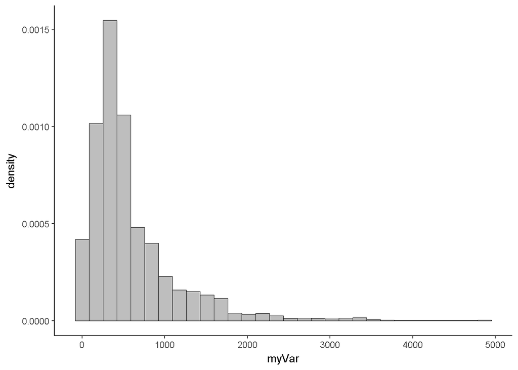

```r
#PLot histogram of data
p1 <- ggplot(data=z, aes(x=myVar, y=..density..)) +
  geom_histogram(color="black",fill="grey",size=0.2) +  theme_classic()
print(p1)
```

## Add emprical density curve [side note: insert code chunk hot key `Ctrl+Alt+I`]

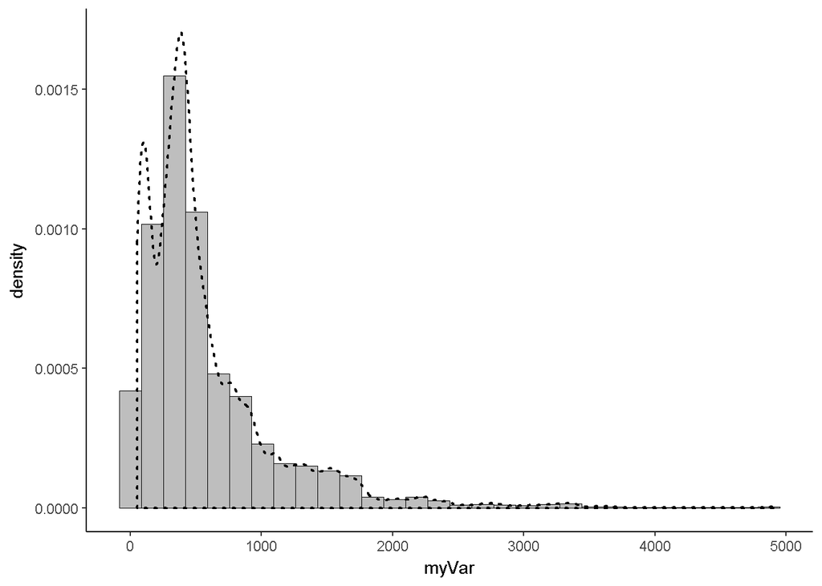

```r
p1 <- p1 + geom_density(linetype="dotted",size=0.75)
print(p1)
```

## Get maximum likelihood parameters for `normal`

```r
normPars <- fitdistr(z$myVar,"normal")
print(normPars)
```

```
##       mean          sd
##   595.987547   581.354233
##  (  3.130723) (  2.213755)
```

```r
str(normPars)
```

```
## List of 5
##  $ estimate: Named num [1:2] 596 581
##   ..- attr(*, "names")= chr [1:2] "mean" "sd"
##  $ sd      : Named num [1:2] 3.13 2.21
##   ..- attr(*, "names")= chr [1:2] "mean" "sd"
##  $ vcov    : num [1:2, 1:2] 9.8 0 0 4.9
##   ..- attr(*, "dimnames")=List of 2
##   .. ..$ : chr [1:2] "mean" "sd"
##   .. ..$ : chr [1:2] "mean" "sd"
##  $ n       : int 34482
##  $ loglik  : num -268418
##  - attr(*, "class")= chr "fitdistr"
```

```r
normPars$estimate["mean"] # note structure of getting a named attribute
```

```
##     mean
## 595.9875
```

## Plot `normal` probability

```r
meanML <- normPars$estimate["mean"]
sdML <- normPars$estimate["sd"]

xval <- seq(0,max(z$myVar),len=length(z$myVar))

 stat <- stat_function(aes(x = xval, y = ..y..), fun = dnorm, colour="red", n = length(z$myVar), args = list(mean = meanML, sd = sdML))
 p1 + stat
```

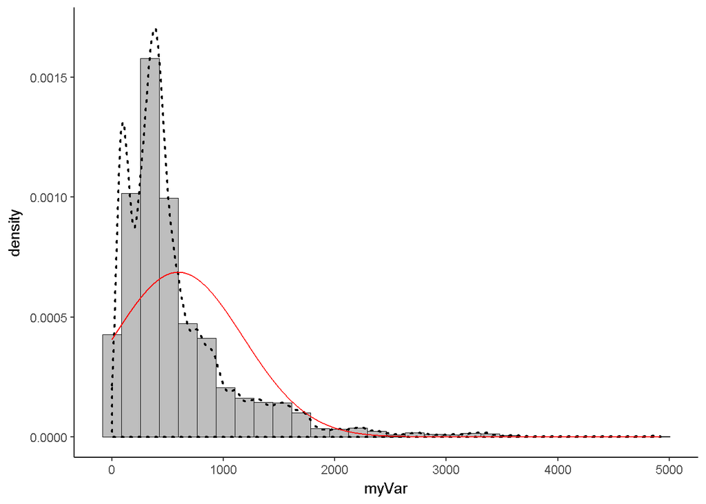

## Plot `exponential` probability density

```r
expoPars <- fitdistr(z$myVar,"exponential")
rateML <- expoPars$estimate["rate"]

stat2 <- stat_function(aes(x = xval, y = ..y..), fun = dexp, colour="blue", n = length(z$myVar), args = list(rate=rateML))
 p1 + stat + stat2
```

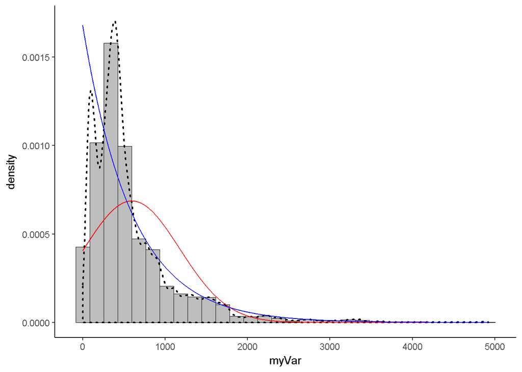

## Plot `uniform` probability density

```r
stat3 <- stat_function(aes(x = xval, y = ..y..), fun = dunif, colour="darkgreen", n = length(z$myVar), args = list(min=min(z$myVar), max=max(z$myVar)))
 p1 + stat + stat2 + stat3
```

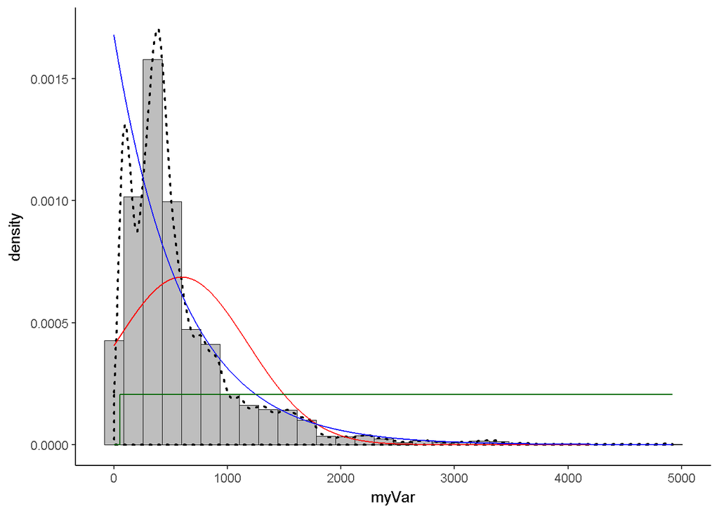

## Plot `gamma` probability density

```r
gammaPars <- fitdistr(z$myVar,"gamma")
shapeML <- gammaPars$estimate["shape"]
rateML <- gammaPars$estimate["rate"]

stat4 <- stat_function(aes(x = xval, y = ..y..), fun = dgamma, colour="brown", n = length(z$myVar), args = list(shape=shapeML, rate=rateML))
 p1 + stat + stat2 + stat3 + stat4
```

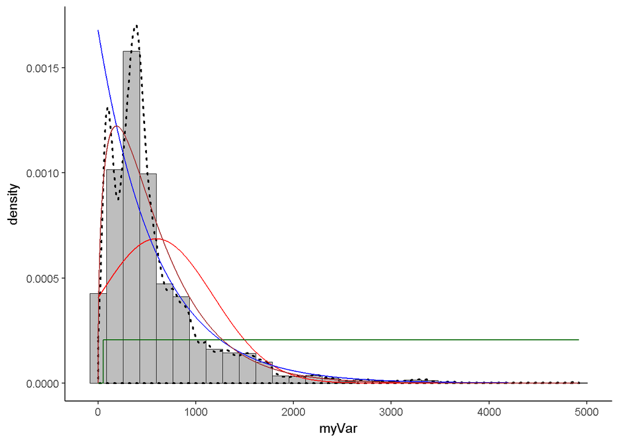

## Plot `beta` probability density

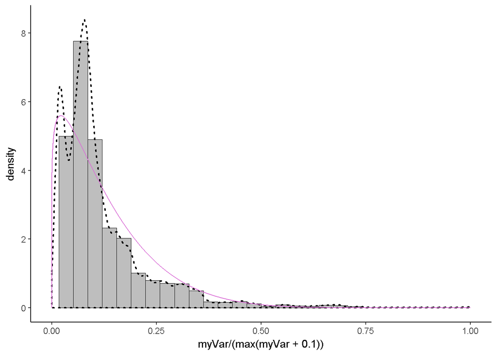

```r
pSpecial <- ggplot(data=z, aes(x=myVar/(max(myVar + 0.1)), y=..density..)) +
  geom_histogram(color="black",fill="grey",size=0.2) +
  xlim(c(0,1)) +
  geom_density(size=0.75,linetype="dotted") +
  theme_classic()

betaPars <- fitdistr(x=z$myVar/max(z$myVar + 0.1),start=list(shape1=1,shape2=2),"beta")
shape1ML <- betaPars$estimate["shape1"]
shape2ML <- betaPars$estimate["shape2"]

statSpecial <- stat_function(aes(x = xval, y = ..y..), fun = dbeta, colour="orchid", n = length(z$myVar), args = list(shape1=shape1ML,shape2=shape2ML))
pSpecial + statSpecial
```

# Compare log likelihood to select

```r
normPars$loglik
```

```
## [1] -268418.2
```

```r
expoPars$loglik
```

```
## [1] -254829.6
```

```r
gammaPars$loglik
```

```
## [1] -253491.3
```

```r
betaPars$loglik
```

```
## [1] 37240.09
```